# **Chapter2: Regression and model validation**

This week I have been learning simple linear regression.

```r
date()
```

```
## [1] "Sat Nov 20 08:55:51 2021"
```

**1.** First, I will read the students2014 data into R from my local folder and explore the structure and the dimensions of the data + also trying out a few other functions.

```r
heididata <- read.table("data/heidindata.csv", sep=",", header=TRUE)
#Explore the structure and the dimensions of the data
str(heididata)
```

```
## 'data.frame':    166 obs. of  8 variables:
##  $ X             : int  1 2 3 4 5 6 7 8 9 10 ...
##  $ sukupuoli     : chr  "F" "M" "F" "M" ...
##  $ lrn14.Age     : int  53 55 49 53 49 38 50 37 37 42 ...
##  $ lrn14.Attitude: num  3.7 3.1 2.5 3.5 3.7 3.8 3.5 2.9 3.8 2.1 ...
##  $ lrn14.deep    : num  3.58 2.92 3.5 3.5 3.67 ...
##  $ lrn14.stra    : num  3.38 2.75 3.62 3.12 3.62 ...
##  $ lrn14.surf    : num  2.58 3.17 2.25 2.25 2.83 ...
##  $ lrn14.Points  : int  25 12 24 10 22 21 21 31 24 26 ...
```

```r
dim(heididata)
```

```
## [1] 166   8
```

```r
head(heididata)
```

```
##   X sukupuoli lrn14.Age lrn14.Attitude lrn14.deep lrn14.stra lrn14.surf
## 1 1         F        53            3.7   3.583333      3.375   2.583333
## 2 2         M        55            3.1   2.916667      2.750   3.166667
## 3 3         F        49            2.5   3.500000      3.625   2.250000
## 4 4         M        53            3.5   3.500000      3.125   2.250000
## 5 5         M        49            3.7   3.666667      3.625   2.833333
## 6 6         F        38            3.8   4.750000      3.625   2.416667
##   lrn14.Points
## 1           25
## 2           12
## 3           24
## 4           10
## 5           22
## 6           21
```

The dataset “heididata” includes 8 variables and 166 observations. It is a subdata of an international survey of Approaches to Learning, which has been collected 3.12.2014 - 10.1.2015. The variables included in the “heididata” are gender, age, attitude, deep learning, strategic learning, surface learning, points and a running variable X.

**2.** Next, I will show a graphical overview of the data and show summaries of the variables in the data. I will also describe and interpret the outputs.

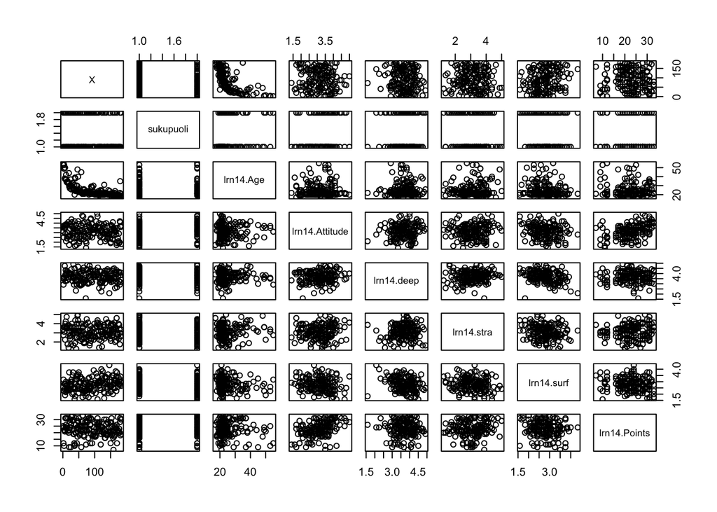

```r
plot(heididata)
```

```r
summary(heididata)
```

```
##        X           sukupuoli           lrn14.Age     lrn14.Attitude
##  Min.   :  1.00   Length:166         Min.   :17.00   Min.   :1.400
##  1st Qu.: 44.25   Class :character   1st Qu.:21.00   1st Qu.:2.600
##  Median : 87.50   Mode  :character   Median :22.00   Median :3.200
##  Mean   : 90.13                      Mean   :25.51   Mean   :3.143
##  3rd Qu.:136.75                      3rd Qu.:27.00   3rd Qu.:3.700
##  Max.   :183.00                      Max.   :55.00   Max.   :5.000
##    lrn14.deep      lrn14.stra      lrn14.surf     lrn14.Points
##  Min.   :1.583   Min.   :1.250   Min.   :1.583   Min.   : 7.00
##  1st Qu.:3.333   1st Qu.:2.625   1st Qu.:2.417   1st Qu.:19.00
##  Median :3.667   Median :3.188   Median :2.833   Median :23.00
##  Mean   :3.680   Mean   :3.121   Mean   :2.787   Mean   :22.72
##  3rd Qu.:4.083   3rd Qu.:3.625   3rd Qu.:3.167   3rd Qu.:27.75
##  Max.   :4.917   Max.   :5.000   Max.   :4.333   Max.   :33.00
```

The age of the respondents is between 17 and 55; attitude approximately 1,4 - 5,0; deep learning approximately 1.6 - 4,9; strategic learning approximately 1,3 - 5,0; surface learning approximately 1,6 - 4,3 and points 7 - 33.

**3.** My regression model explains the target (dependent) variable, exam points, with gender, age and attitude.

```r
my_regression <- lm(lrn14.Points ~ sukupuoli + lrn14.Age + lrn14.Attitude , data = heididata)

#Print out a summary of my regression model
summary(my_regression)
```

```
##
## Call:
## lm(formula = lrn14.Points ~ sukupuoli + lrn14.Age + lrn14.Attitude,
##     data = heididata)
##
## Residuals:
##      Min       1Q   Median       3Q      Max
## -17.4590  -3.3221   0.2186   4.0247  10.4632
##
## Coefficients:
##                Estimate Std. Error t value Pr(>|t|)
## (Intercept)    13.42910    2.29043   5.863 2.48e-08 ***
## sukupuoliM     -0.33054    0.91934  -0.360    0.720
## lrn14.Age      -0.07586    0.05367  -1.414    0.159
## lrn14.Attitude  3.60657    0.59322   6.080 8.34e-09 ***
## ---
## Signif. codes:  0 '***' 0.001 '**' 0.01 '*' 0.05 '.' 0.1 ' ' 1
##
## Residual standard error: 5.315 on 162 degrees of freedom
## Multiple R-squared:  0.2018, Adjusted R-squared:  0.187
## F-statistic: 13.65 on 3 and 162 DF,  p-value: 5.536e-08
```

Next, I will run the regression again with just attitude as the explanatory variable and print out a summary of the regression model:

```r
my_regression2 <- lm(lrn14.Points ~ lrn14.Attitude , data = heididata)
summary(my_regression2)
```

```
##
## Call:
## lm(formula = lrn14.Points ~ lrn14.Attitude, data = heididata)
##
## Residuals:
##      Min       1Q   Median       3Q      Max
## -16.9763  -3.2119   0.4339   4.1534  10.6645
##
## Coefficients:
##                Estimate Std. Error t value Pr(>|t|)
## (Intercept)     11.6372     1.8303   6.358 1.95e-09 ***
## lrn14.Attitude   3.5255     0.5674   6.214 4.12e-09 ***
## ---
## Signif. codes:  0 '***' 0.001 '**' 0.01 '*' 0.05 '.' 0.1 ' ' 1
##
## Residual standard error: 5.32 on 164 degrees of freedom
## Multiple R-squared:  0.1906, Adjusted R-squared:  0.1856
## F-statistic: 38.61 on 1 and 164 DF,  p-value: 4.119e-09
```

**4.** Since gender and age did not have a statistically significant effect, I will analyze the summary of the my_regression2 with attitude as the explanatory variable.

The coefficient is 3.5255, meaning that when the explanatory variable (attitude) moves one unit, the target variable moves 3.5255 units. One unit better attitude, should result in 3.5255 more points!

The multiple R squared of the model is 0.1906. This means that approximately 19.1% the variation in points is explained by the variation in attitude.

**5**

In linear regression model we need to assume linearity as well as that the errors are normally distributed, the errors are not correlated, the errors have constant variance, the size of a given error does not depend on the explanatory variables.

A boxplot or probability plot of the residuals can be useful in checking for symmetry and specifically the normality of the error terms in the regression model.

Plotting the **residuals against the fitted values** of the response variable. If the variability of the residuals appears to increase with the size of the fitted values, a transformation of the response variable prior to fitting is indicated.

the **QQ-plot of the residuals** provides a method to explore the assumption that the errors are normally distributed.

**Residuals vs. leverage plot** can help identify which observations have an unusually high impact.

I am using the linear model object “my_regression” with several explanatory variables that was created earlier

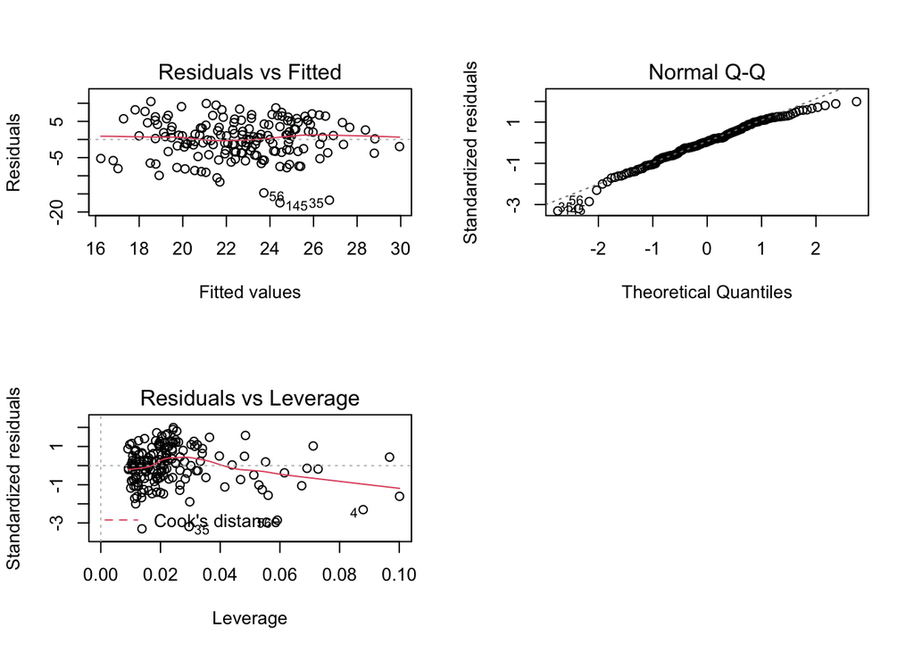

```r
#Let's place the following 4 graphics to the same plot:
par(mfrow = c(2,2))

#Calling the plot function with 1 (Residuals vs Fitted values), 2 (Normal QQ-plot) & 5 (Residuals vs Leverage).
plot(my_regression,which=c(1,2,5))
```

**Residuals vs. fitted values** looks pretty much what is looked for to confirm that the fitted model is appropriate. Seems that assumption of constant variance is justified.

In the **QQ plot of the residuals** there is a small dip in the beginning and in the end which might cause a small worry for the the assumption that the errors are normally distributed.